# Interference: Constructive and Destructive — Student Worksheet

**Unit: Waves — Lesson 05** Name: _______________________ Date: __________ Period: ____

## Phenomenon

Two speakers play the exact same steady tone. As you walk across the room, the volume rises and falls — some spots are loud, some are nearly silent — and nobody touched the volume knob. Noise-canceling headphones do something even stranger: they add sound to create silence.

**Driving question:** How can adding a second wave make a spot *quieter*?

## Notice & Wonder

| I notice… | I wonder… |
| --- | --- |

**Turn & Talk #1:** What would have to be true about two waves arriving at a quiet spot for them to cancel?

## Initial Model

Draw two waves arriving at the same point. Draw one version that makes a **LOUD** spot and one that makes a **QUIET** spot. What is different about how the crests line up?

## Investigation

Work in your random group of 3 at a vertical surface (one marker). Solve each task, then confirm in Javalab.

| Task | Sketch the sum | What I found |
| --- | --- | --- |
| 1. Crest-on-crest |  |  |
| 2. Crest-on-trough |  |  |
| 3. Shift one wave by ½ wavelength |  |  |
| 4. Why does covering one speaker make a quiet spot loud? |  |  |

Compare your sketches to these:

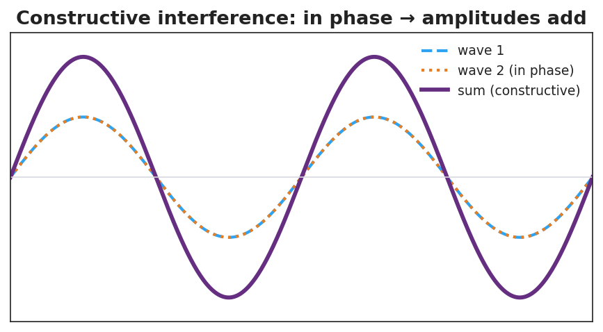

Two in-phase waves adding to a larger wave — constructive interference.

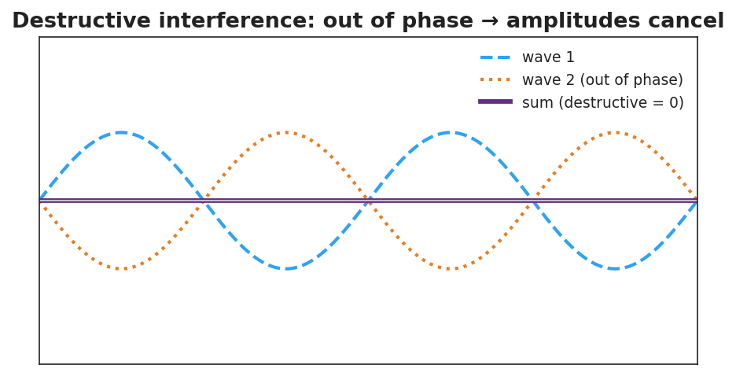

Two out-of-phase waves canceling to a flat line — destructive interference.

**Key question:** When two waves cancel at a quiet spot, where did the energy go? Is it gone everywhere?

## Make It Make Sense

1. State the principle of **superposition** in your own words.
2. Two waves of amplitude 3 cm meet exactly in phase. What is the resulting amplitude? What if they meet exactly out of phase?
3. Explain how noise-canceling headphones make a hum disappear. Use the term *destructive interference*.

## Vocabulary in Action

Use each term in a sentence about today’s phenomenon.

- **superposition:** _______________________________________________
- **constructive interference:** _______________________________________________
- **destructive interference:** _______________________________________________

## Revise Your Model

Return to your loud-spot and quiet-spot drawings. Label one **constructive** and one **destructive**. Add a sentence using the word *superposition*.

## Exit Ticket

Two speakers play the same tone. At one point in the room a listener hears almost nothing.

1. Is this constructive or destructive interference?
2. Describe how the two waves are arriving at that point (in phase or out of phase?).
3. Two waves of amplitude 4 cm meet exactly in phase. What is the resulting amplitude?